# Custom Service Protocol Firmware - Low Power Variant

# Overview

This sample program implements Custom Service Protocol over BLE to communicate with **RSL10 Sense and Control** Android or iOS mobile applications.

This example is meant to be used with the RSL10-SENSE-DB-GEVK evaluation board and exposes data from its on-board sensors:

- NOA1305 - Ambient light sensor node providing ambient light readings in Lux.
- BME680 - Environmental sensor node providing ambient temperature, relative humidity, atmospheric pressure and optionally indoor air quality data.
- BHI160B with BMM150 - Smart sensor hub with external magnetometer providing Nine degrees of freedom orientation data.

This application can enter one of the following states:

- **Advertising mode**  
  Default state after power up. All sensors are disabled in this mode with exception of BME680 which is managed by BSEC. Board periodically sends advertising packets (1s interval by default) to allow other devices to connect to it.

  If no device connects in defined timeout period (default 60s) the device will enter sleep mode. Switch to sleep mode is indicated by blue LED blinking once.
- **Sleep mode**  
  In this mode all BLE advertising activity is stopped and all sensors are disabled.

  The RSL10 wakes up periodically (default 1.5s) to check if button PB1 is pressed. If button is pressed it will enter Advertising mode signaled by short blink of green LED.
- **Connected Mode**  
  This mode can be entered from Advertising mode when a device connects to the board. BLE connection will be maintained based on parameters set by master device.

  In this mode sensors can be turned on if master requests sensor related data:
  - *NOA1305* - Sensor will be enabled after an ambient light request was received. Sensor will be put back to sleep after measurement result is send back to peer device.
  - *BME680* - Sensor is activated independently based on BSEC sampling rate which can be either every 3 seconds or every 5 minutes. Environmental data requests will return data from latest measurement.
  - *BHI160B + BMM150* - This sensor hub consists of accelerometer, gyroscope, magnetometer and fusion core.

    Physical sensors will be enabled when first request for virtual sensor output that requires it is received. Requests for acceleration will use only accelerometer. Requests for absolute orientation will result in all sensors being activated. Activated sensors will remain enabled until peer device disconnects.

  When peer device disconnects the board will enter back into advertising mode.

# Hardware Requirements

Compatible evaluation boards:

- RSL10-SENSE-DB-GEVK
  - 3V Lithium CR2032 battery is required for proper operation.
- RSL10-SENSE-GEVK
  - 3V Lithium CR2032 battery is required for proper operation.
  - It is required to either solder 10-pin debugging header or use 10-pin needle connector to program / debug the board.
  - Debug probe is not included with the board.

[figure not shown]

RSL10-SENSE-DB-GEVK connected to PC using SEGGER JLink Lite debugging probe

# Verification

After the program is flashed and running on RSL10-SENSE-GEVK board it will start connectable advertising over BLE. Android application **RSL10 Sense & Control** can be used to show data measured by device sensors. See *Using mobile application* section below for instructions on how to configure and use this application.

The RSL10-SENSE boards expose the following Sensors / Actuators in the application:

- ALS-NOA1305
- Environmental
- Pressure
- Humidity
- Temperature
- Gyroscope
- Accelerometer
- Magnetometer
- Indoor Air Quality (if enabled)

Additional sensor values can be read by adding custom sensor components based on the IDK Custom Service specification. This specification can be found in the *docs* folder of the CMSIS-Pack.

# Configuration

Certain parameters of the application can be configured using an RTE configuration header. This file is located in the *include* folder of the application and is called *RTE_app_config.h* After opening this file using the *CMSIS Configuration Wizard* editor it will show all available configuration options.

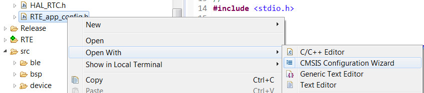

Selecting CMSIS Configuration Wizard to open the configuration file.

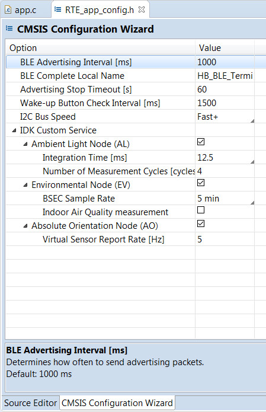

All configurable parameters of this application as shown in CMSIS Configuration Wizard

# Flashing / Debugging Setup

## Selecting Build Configuration

This program contains two build configurations:

1. **Debug**  
   Program is compiled without optimizations and contains debugging symbols. (-g -O0)

Debugging messages are printed over UART interface. The GIO pad of extension header is used as UART TX signal. The serial port uses the following configuration: 230400 bps, 8N1, no handshake. These parameters can be changed in the *app_trace.c* file.

2. **Release**  
   No debugging messages. Compiler optimizes the code. (-Os)

To switch between these configurations click the down arrow next to Build button (hammer icon), select desired build configuration and build project.

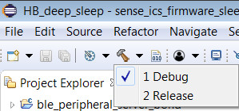

Build selection dialog

## Flashing program using Eclipse Debugger

1. Build the project

[figure not shown]

   eclipse_build

2. Refresh project

   Needed only once to make sure that Eclipse is aware of the built executable.

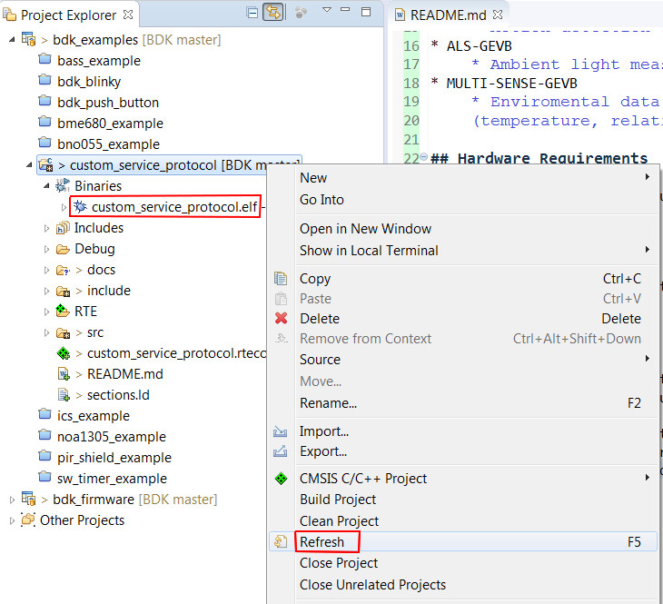

   eclipse_refresh_project

3. Create debug configuration
   1. Open Debug configurations window (Run -> Debug Configurations).

[figure not shown]

   eclipse_debug_configurations

   2. Create *GDB SEGGER J-Link Debugging* debug configuration by double clicking it in window. A new debug configuration will appear with the name of selected project and selected build configuration.
   3. Use the **Search Project…** button to select desired binary from either Debug folder or Release folder.
   4. Press Debug button in the bottom right corner of the window.
   5. When Eclipse switches to debugging perspective press Resume button to run the program.

   6. Since this application utilizes deep sleep mode of RSL10 the debugger will be disconnected a few seconds after the program is started. This is normal since debugging logic of RSL10 is disabled when in deep sleep.

   Debugging of the program using breakpoints is possible only before RSL10 enters sleep mode. UART can be used for printing of debug messages when RSL10 is awake between sleep cycles.
   6. Terminate the debugging session before attempting to:
   - Flash new program into the board.
   - Disconnect target board from debugger board or power supply.

The program loaded using debugger will be saved into RLS10 flash memory and will be automatically executed after the board is restarted.

## Using mobile application

1. Open **RSL10 Sense and Control** application on your smart phone.

   Select receive mode if starting it for the first time.
2. Switch to *Receive over BLE* mode.

   Open the settings page by clicking the gear icon in top right corner. The settings page needs to show:
   - *Enable Broadcast* slider is off
   - *Manage Receive Channel* is set to *Receive via BLE*

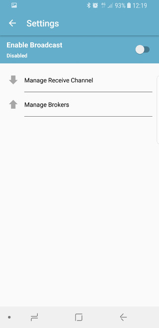

   app_settings

3. Connect to running *HB_BLE_Terminal* device.

   Each device is identified by its name and MAC address. Device can be assigned a custom name by clicking the three dots on right side.

   Device name can also be changed in the RSL10 program.

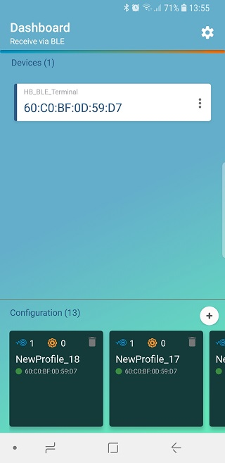

   app_home_screen

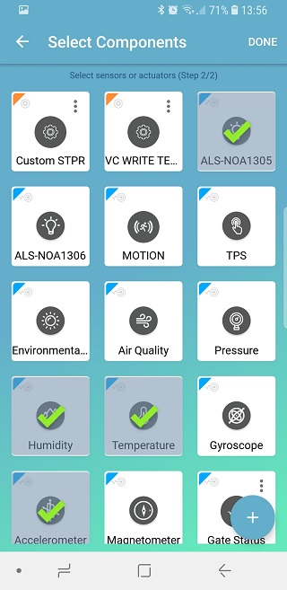

   app_components

5. Observe sensor data being received and updated in the app.

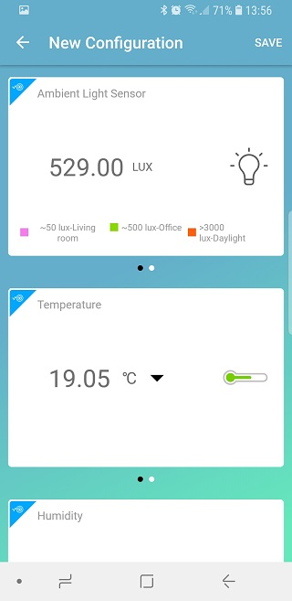

   app_sensor_data

6. Optionally save this configuration for quick access in the future.

# Notes

Sometimes the firmware in RSL10 cannot be successfully re-flashed, due to the application going into Sleep Mode or resetting continuously (either by design or due to programming error). To circumvent this scenario, a software recovery mode using DIO12 can be implemented with the following steps:

1. Connect DIO12 to ground by pressing the PB2 push button.
2. Press the RESET button (this restarts the application, which will pause at the start of its initialization routine).
3. Re-flash RSL10. After successful re-flashing, disconnect DIO12 from ground, and press the RESET button so that the application will work properly.

Copyright (c) 2018 Semiconductor Components Industries, LLC (d/b/a ON Semiconductor).